# L05 Toolbox

Data Visualization (STAT 302)

## Overview

The goal of this lab is to explore more useful plots in `ggplot2`. Specifically we will be focusing on surface plots and geospatial plots (maps).

Challenges are not mandatory for students to complete. We highly recommend students attempt them though. *We would expect graduate students to attempt the challenges.*

## Datasets

We’ll be using data from the `blue_jays.rda`, `cdc.txt`, and the `US_income.rda` datasets which are already in the `/data` subdirectory in our **data_vis_labs** project.

```r
# Load package(s)

# Load datasets

# Read in the cdc dataset
cdc <- read_delim(file = "data/cdc.txt", delim = "|") %>%
  mutate(genhlth = factor(genhlth,
    levels = c("excellent", "very good", "good", "fair", "poor")
  ))
```

## Exercises

Complete the following exercises.

### Exercise 1

Using `blue_jays.rda` dataset, recreate the following graphic as precisely as possible.

*Hints:*

- `geom_density_2d()` or `stat_density_2d()`
- Transparency is 1/3
- Horizontal lower limit is 57 and upper limit is 82
- Point size 1.5
- Line size is 0.4
- `binwidth` set to 0.004
- Minimal theme

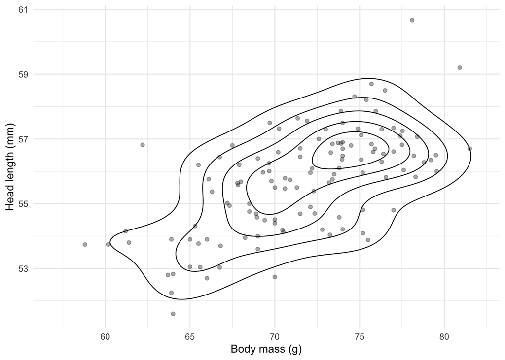

### Exercise 2

Using `cdc` dataset, recreate the following graphics as precisely as possible.

##### Plot 1

*Hints:*

- `bins` set to 35
- Minimal theme

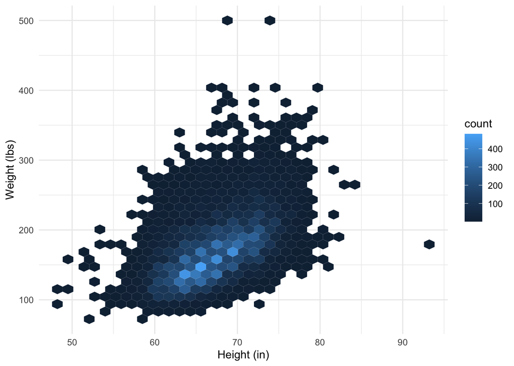

##### Plot 2

*Hints:*

- `polygon`
- Minimal theme

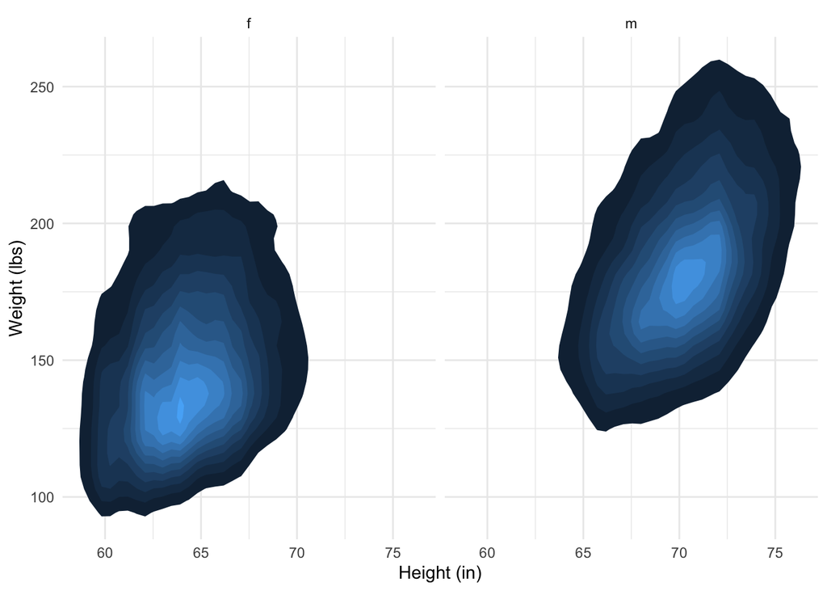

### Exercise 3

Make a county map of a US state. Maybe use your home state (mine is below) or a favorite state. Please do not use the the state in example provided in the book

*Hints:*

- See section 3.7.1 in *ggplot2*
- Void theme

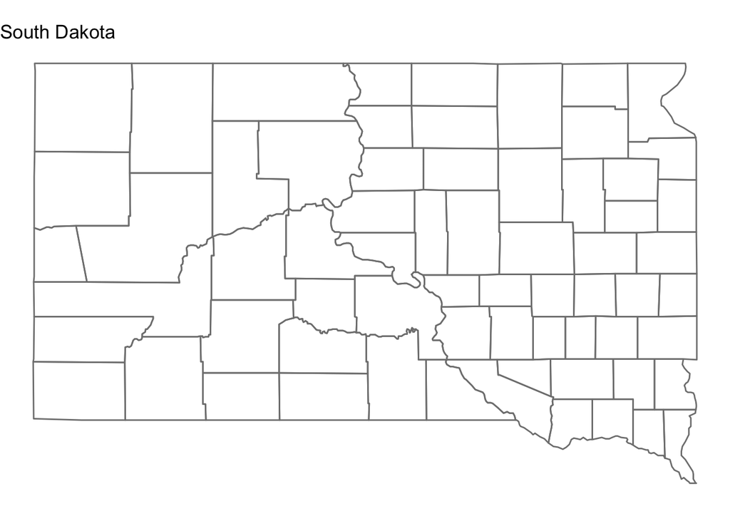

### Exercise 4

Using `US_income` dataset, recreate the following graphics as precisely as possible.

```r
# Setting income levels
US_income <- mutate(
  US_income,
  income_bins = cut(
    ifelse(is.na(median_income), 25000, median_income),
    breaks = c(0, 40000, 50000, 60000, 70000, 80000),
    labels = c("< $40k", "$40k to $50k", "$50k to $60k", "$60k to $70k", "> $70k"),
    right = FALSE
  )
)
```

##### Plot 1

*Hints:*

- `geom_sf()` — boundary color is `"grey80"` and size is 0.2
- `viridis` package (`discrete = TRUE` in `scale_*` function)
- Void theme

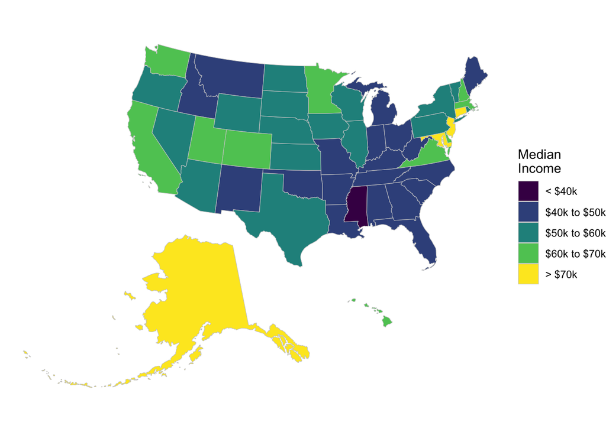

##### Plot 2

*Hints:*

- [Download developmental version](https://github.com/hrbrmstr/statebins) of `statebins` package
- `geom_statebins()`
- `viridis` package (`discrete = TRUE` in `scale_*` function)
- Statebins theme

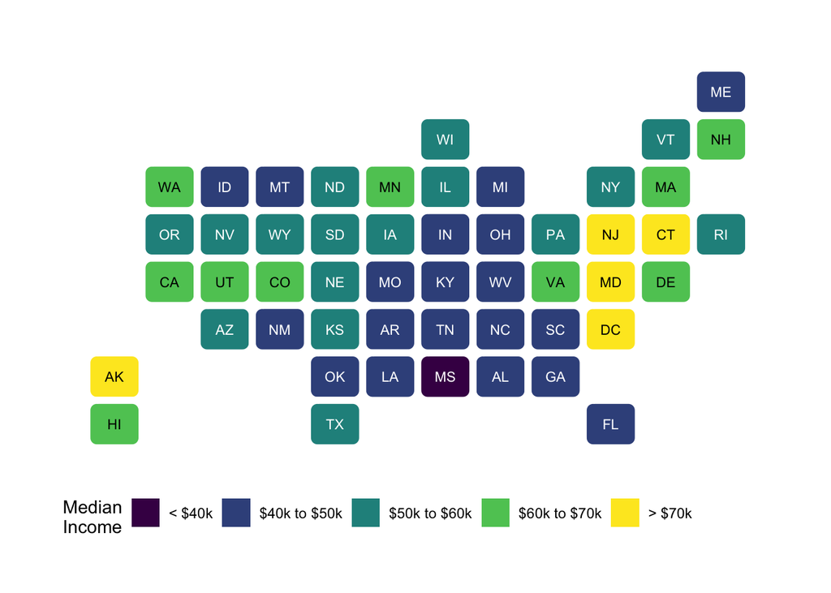

## Challenge(s)

Using the `tidycensus` package and few others, try to create a map like below using [these directions](https://walkerke.github.io/tidycensus/articles/spatial-data.html). Try using a different geographical area and a different variable from the ACS.

[interactive chart not shown]